# How Trade Agreements Organize Markets

Stephen Weymouth

Dean’s Professor

2026-09-16

## Apparel remained protected as other tariffs fell

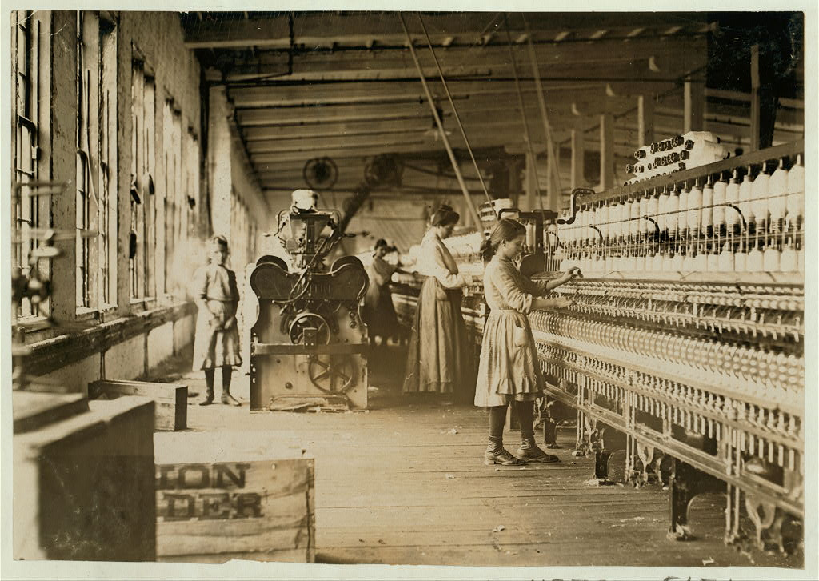

Lewis Hine, 1908 · [Library of Congress](https://www.loc.gov/item/2018674973/), public domain.

### After the Tokyo Round, 1979

**6.5%** average U.S. tariff on manufactured goods.

**22.5%** average U.S. tariff on apparel.

What explains this difference?

Trade agreements change the cost of crossing a border.

[Rivoli, “Dogs Snarling Together”](https://drive.google.com/file/d/18LeRC7z6NR7mPX2a5VuFSID7KFQHItjh/view); historical averages reported in the assigned chapter.

## Your IB Voice

Question

What was the political logic behind the Multifiber Arrangement? Whose problem did it solve, and what did each side give up?

**10 minutes** · Individual · Notes permitted · No internet or LLMs

## Explanations

Whose problem did the Multifiber Arrangement solve?

Who won and who lost?

# The Politics of Trade Policy

## Three objectives shaped U.S. tariff policy

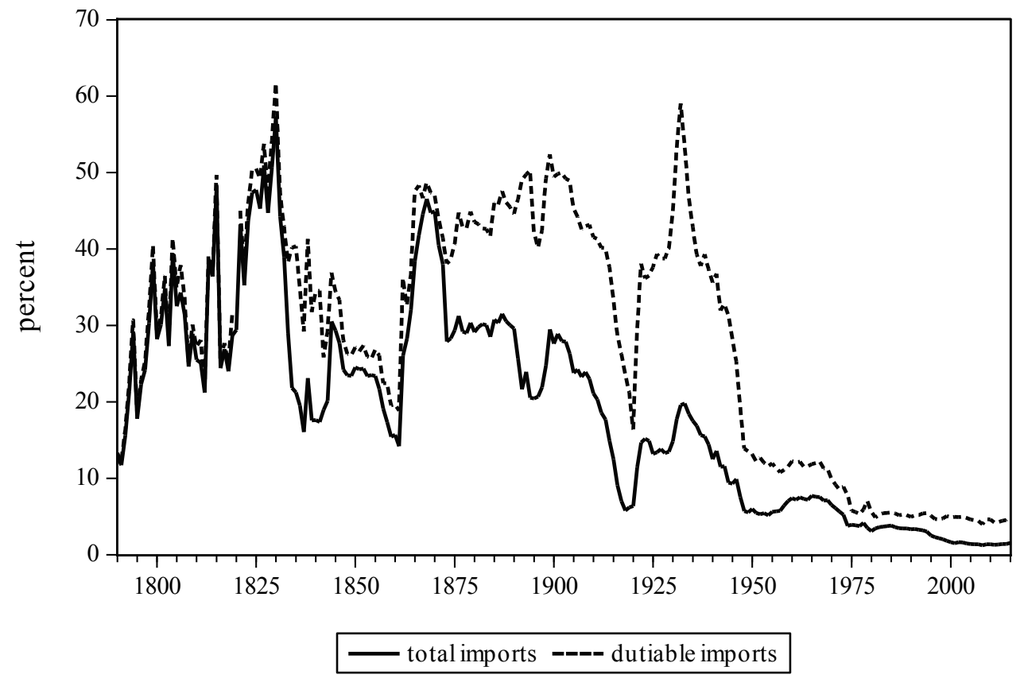

| Product | Tariff | Import value |
| --- | --- | --- |
| A | 5% | $500,000 |
| B | 12% | $200,000 |
| C | 0% | $300,000 |

**Weighted average:** (5% × $500,000 + 12% × $200,000 + 0% × $300,000) ÷ $1,000,000 = **4.9%**.

Import value equals price × quantity. Holding quantities fixed, a higher price for Product B gives the 12% tariff more weight and raises the average. The total imports tariff includes Product C at 0%. The dutiable-import average excludes Product C.

### Revenue: 1790–1860

Duties financed the federal government.

### Restriction: 1860–1934

Protection supported domestic producers.

### Reciprocity: from 1934

Negotiated cuts opened foreign markets.

The Civil War and then the Great Depression changed the objective.

[Irwin, Introduction](https://www.nber.org/system/files/chapters/c13850/c13850.pdf), pp. 2–8, Figure I.1 (original figure, cropped from p. 6).

## Regional interests persisted in congressional votes

### Tariff vote, 1828

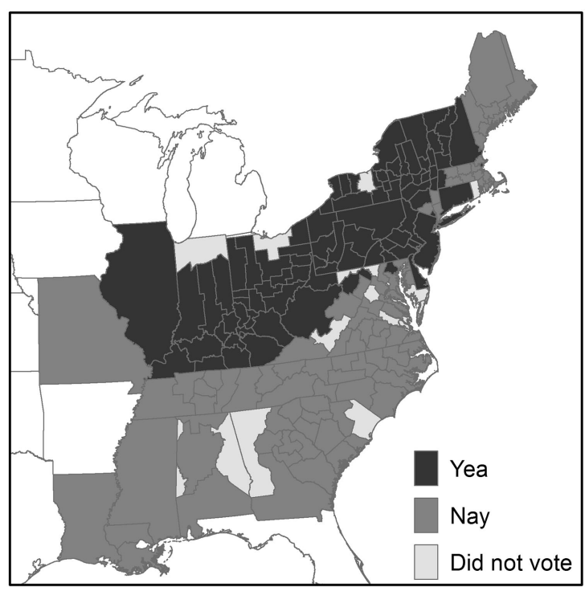

### Tariff vote, 1929

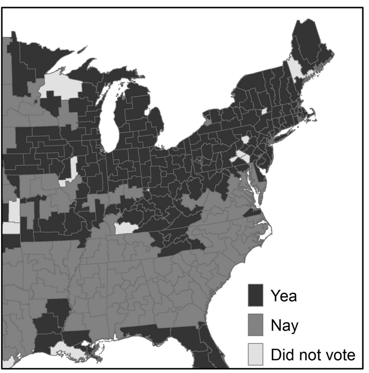

Exporting regions sought market access. Import-competing regions sought protection. Congress (institution) translates these interests into tariff policy.

[Irwin, Introduction](https://www.nber.org/system/files/chapters/c13850/c13850.pdf), pp. 10–16, Figure I.5; maps by Citrin GIS/Applied Spatial Analysis Lab, Dartmouth College. Cropped from p. 16.

## A general model of trade policy

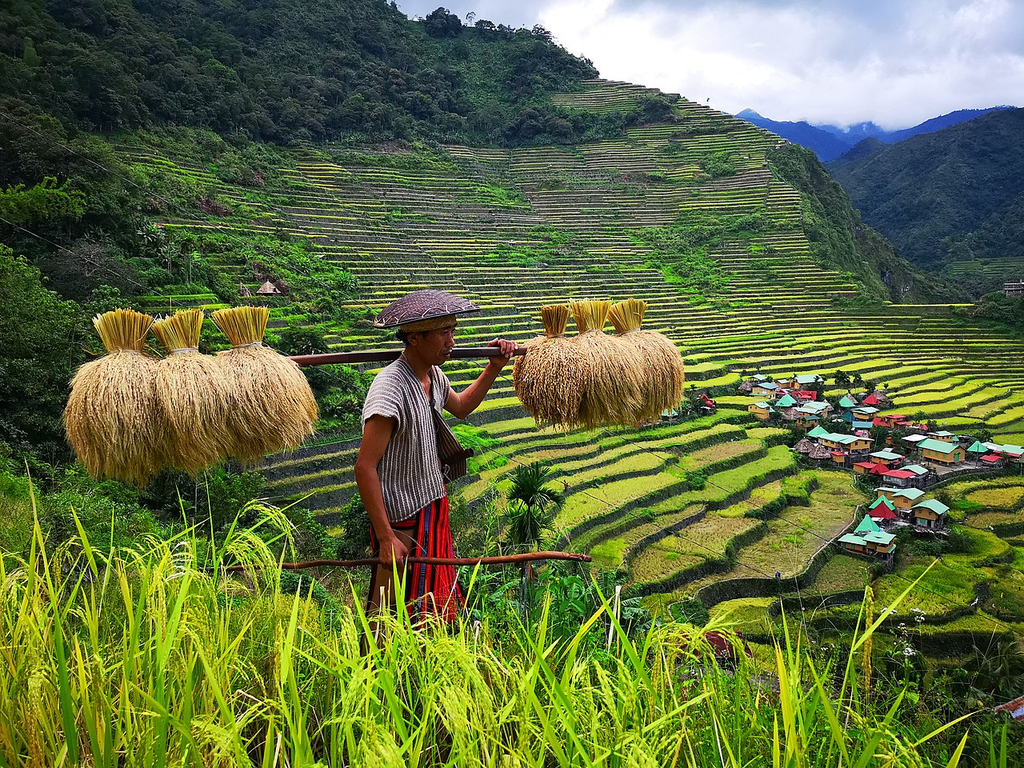

### Regional economic interests

Exporters seek market access. Import-competing producers seek protection.

→

[figure not shown]

### Political institutions

Institutions filter competing demands. Electoral rules shape representation. Trade authority determines who decides.

→

[figure not shown]

### Trade policy

Governments set tariffs and quotas. They also negotiate trade agreements.

Political institutions filter regional interests, so similar interests can produce different trade policies across countries.

Raniel Jose Castaneda, [rice terraces, Philippines](https://commons.wikimedia.org/wiki/File:Rice_Terraces_of_the_Philippines.jpg), CC BY-SA 4.0; [European Parliament](https://commons.wikimedia.org/wiki/File:European_Parliament_Hemicycle_-_Brussels_2024.jpg), CC0; William Cho, [Port of Singapore](https://commons.wikimedia.org/wiki/File:The_port_of_Singapore.jpg), CC BY-SA 2.0.

## Concentrated gains > diffuse costs

[figure not shown]

### Protected producers

A tariff can concentrate jobs and profits in a few firms and districts. Each firm has a strong reason to organize.

### Consumers and retailers

The added cost spreads across many purchases. Each buyer has less reason to lobby. Retailers gained influence after organizing in the 1980s.

Political strength follows the incentive and capacity to organize.

James Madison Wikimedia Commons.

## 1934: Congress delegated tariff negotiation to Executive

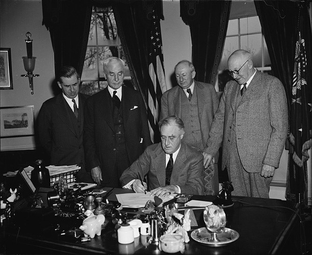

### A different procedure

The president could cut tariffs by up to half in exchange for foreign cuts.

Agreements took effect by presidential proclamation, with no vote on each one.

### A different objective

Cordell Hull linked reciprocal trade liberalization to peace and international cooperation.

The Depression shifted political power. Hull supplied an alternative policy and a reason to pursue it.

[Irwin, Introduction](https://www.nber.org/system/files/chapters/c13850/c13850.pdf), pp. 21–27; [U.S. Tariff Commission, historical account](https://www.usitc.gov/sites/default/files/publications/332/otap_1_part_2_optimized.pdf), p. 1; [USTR photograph](https://ustr.gov/about-us/policy-offices/press-office/blog/2014/June/Eighty-years-of-the-Reciprocal-Trade-Agreements-Act).

## The Reciprocal Trade Agreements Act

01

### Congress set tariffs

Congress wrote product-specific rates. Members bargained for industries in their districts.

02

### Pressure for change

The Depression and foreign retaliation exposed the costs of high tariffs.

03

### Congress delegated

The RTAA authorized the president for three years. Tariff reductions were capped at 50%.

04

### The president negotiated

Reciprocal agreements took effect without a new congressional vote on each deal.

**Outcome by 1946:** Agreements with 27 countries affected nearly 2,000 U.S. products and provided a model for GATT.

[U.S. International Trade Commission, *History of U.S. Trade Policy Since 1934*](https://www.usitc.gov/publications/332/us_trade_policy_since1934_ir6_pub4094.pdf), pp. 73-75; [USITC, *Reversing Protectionism*](https://www.usitc.gov/publications/332/working_papers/2024-12-a_reversing_protectionism.pdf), pp. 4-6.

# MFN and Trade Preferences

## MFN: a tariff cut for one member is a tariff cut for all

Countries A, B, C, and D are all GATT/WTO members. A cuts its shirt tariff from 10% to 5% in exchange for a cut by B on A’s exports.

[figure not shown]

GATT Article I: Country A cannot favor one member over another. C and D get the 5% rate without giving anything in return.

[GATT, Article I](https://www.wto.org/english/docs_e/legal_e/gatt47_e.htm). Hypothetical countries and rates; photograph on preceding divider: WTO, GATT signing, 1947.

## A free trade agreement keeps the cut from non-members

A and B form a free trade area. Shirts from B now enter A at 0%. Shirts from C and D still pay the 5% MFN rate.

[figure not shown]

GATT Article XXIV allows this exception to MFN. It works only if A can tell a shirt made in B from a shirt that passed through B.

[GATT, Articles I and XXIV](https://www.wto.org/english/docs_e/legal_e/gatt47_e.htm). Hypothetical countries and rates.

# Textiles: Protection and Bargaining

## Textile protection supported broader trade bargains

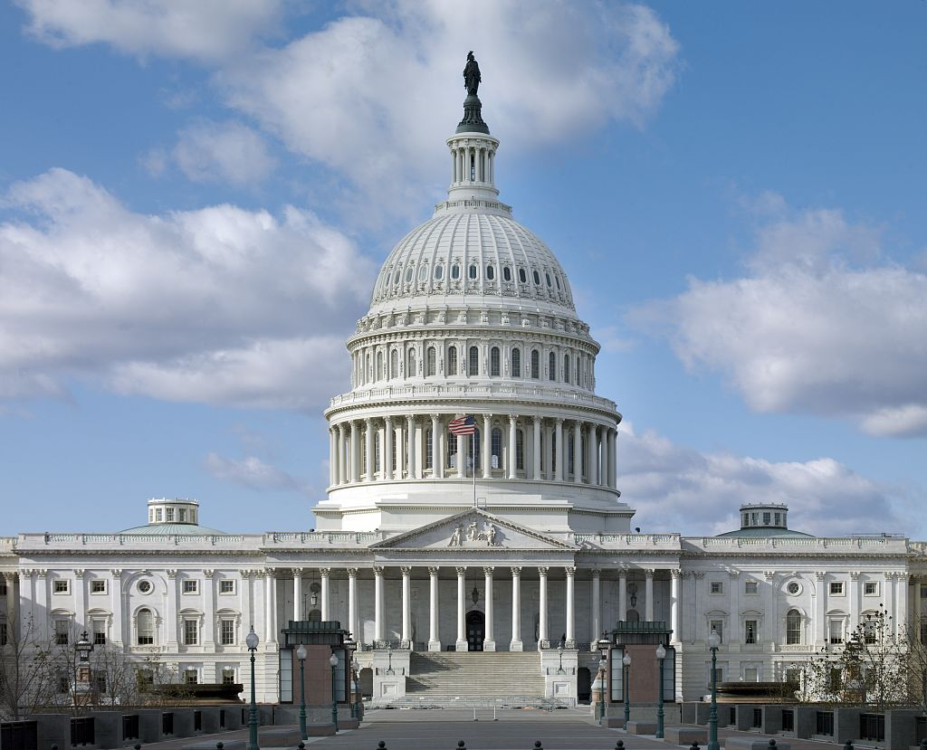

### Kennedy, 1961–62

Cotton quotas helped secure textile-industry support for broader trade liberalization.

### Reagan, 1980

He promised to limit import growth to growth in the domestic market. Existing agreements made that promise impossible to fulfill.

Southern concentration helped the industry organize. Unfulfilled promises also generated pressure for stronger protection.

[Rivoli, “Dogs Snarling Together”](https://drive.google.com/file/d/18LeRC7z6NR7mPX2a5VuFSID7KFQHItjh/view), especially the presidential promises and textile coalition. Background photograph on preceding divider: Lewis Hine, North Carolina, 1908, Library of Congress.

## Quotas redirected imports across places and products

[figure not shown]

Museum exhibit, 2008 · InSapphoWeTrust, Wikimedia Commons, CC BY-SA 2.0.

### Japan quota → Hong Kong

U.S. cotton-goods imports from Hong Kong rose **nearly 700%**, 1956–61.

### Cotton quotas → other fibers

U.S. synthetic-fiber imports from developing countries rose **2,500%**, 1964–70.

The **Multifiber Arrangement (MFA), 1974**, extended quotas to more countries and fibers as producers changed sourcing routes.

[Rivoli, “Dogs Snarling Together”](https://drive.google.com/file/d/18LeRC7z6NR7mPX2a5VuFSID7KFQHItjh/view), discussion of the Eisenhower-era Japanese restraint (Rivoli does not date it; 1957 is external), cotton arrangements, and the MFA.

## Global sourcing divided the textile coalition

[figure not shown]

Retailers organized for easier imports. Developing-country exporters sought an end to the MFA in exchange for concessions in services and intellectual property.

[Rivoli, “Dogs Snarling Together”](https://drive.google.com/file/d/18LeRC7z6NR7mPX2a5VuFSID7KFQHItjh/view), discussion of retailer organization, upstream conflicts, and the International Textiles and Clothing Bureau.

## The textile coalition could no longer overcome a veto

[figure not shown]

The 1985 Jenkins bill had **230 cosponsors** and would have imposed stronger global textile quotas.

Protection still commanded a large House majority. The coalition fell eight votes short of overriding President Reagan’s veto.

[Rivoli, “Dogs Snarling Together”](https://drive.google.com/file/d/18LeRC7z6NR7mPX2a5VuFSID7KFQHItjh/view), Jenkins bill and override discussion.

## The end of textile quotas, 1995–2005

### 1995

**The agreement begins**

The Agreement on Textiles and Clothing (ATC) gives governments ten years to eliminate the Multifiber Arrangement quotas.

### 1995–2004

**Governments delay sensitive products**

Early targets count products that already face no quota. About **85% of actual quotas remain** at the end of 2004.

### 2005

**The deadline arrives**

The remaining MFA quotas end. Tariffs and other trade rules continue.

The ATC ended quotas on a schedule, while governments postponed politically sensitive products until the deadline.

[Rivoli, “Dogs Snarling Together”](https://drive.google.com/file/d/18LeRC7z6NR7mPX2a5VuFSID7KFQHItjh/view); [WTO, Agreement on Textiles and Clothing](https://www.wto.org/english/tratop_e/texti_e/texintro_e.htm).

## The New MFA Logic

For forty years, presidents gave the textile industry quotas so that U.S. trade liberalization of other sectors could proceed.

In the Uruguay Round the United States gave up the MFA so that **developing countries** would accept liberalization of U.S. services and intellectual property.

[Rivoli, “Dogs Snarling Together”](https://drive.google.com/file/d/18LeRC7z6NR7mPX2a5VuFSID7KFQHItjh/view), the Uruguay Round and the ITCB.

# Rules of Origin Activity

## Should sewing in Honduras make the shirt regional?

A rule of origin says which production steps must happen inside the region for the finished garment to enter the United States duty-free.

[figure not shown]

Inside the region means the United States, five Central American countries, and the Dominican Republic.

The fabric comes from outside CAFTA-DR. Honduras cuts and sews the shirt. Should that be enough for duty-free entry?

[U.S. Department of Commerce, CAFTA-DR textiles](https://www.trade.gov/summary-cafta-fta-textiles). Historical teaching example; product-specific rules and exceptions apply.

## Negotiate a rule of origin

You will be assigned one industry role.

**1. U.S. yarn spinner**

**2. U.S. fabric mill**

**3. Honduran sewing plant**

**4. U.S. apparel brand**

**5. Asian fabric mill**

**6. U.S. retailer**

**Production stages:** Cotton grown → Yarn spun → Fabric knit → Garment sewn

1. **Advocate:** Which stages should the agreement require within CAFTA-DR?
2. **Explain:** How does your rule affect your business?

**5-10 minutes** · One rule

## CAFTA-DR generally uses a yarn-forward rule

[figure not shown]

### What qualifies

Yarn spinning, fabric production, and garment assembly occur within CAFTA-DR. Cotton may come from outside the region.

### The exception

Garments containing yarns or fabrics on the short-supply list still qualify, even though those inputs are made outside the region.

Only garments made from regional yarn and fabric qualify, which is what creates demand for both. The short-supply list lets a garment qualify with listed foreign inputs.

[U.S. Department of Commerce, CAFTA-DR textiles](https://www.trade.gov/summary-cafta-fta-textiles). See the general yarn-forward rule and commercial-availability exceptions.

# Regional Integration

## Three levels of regional integration

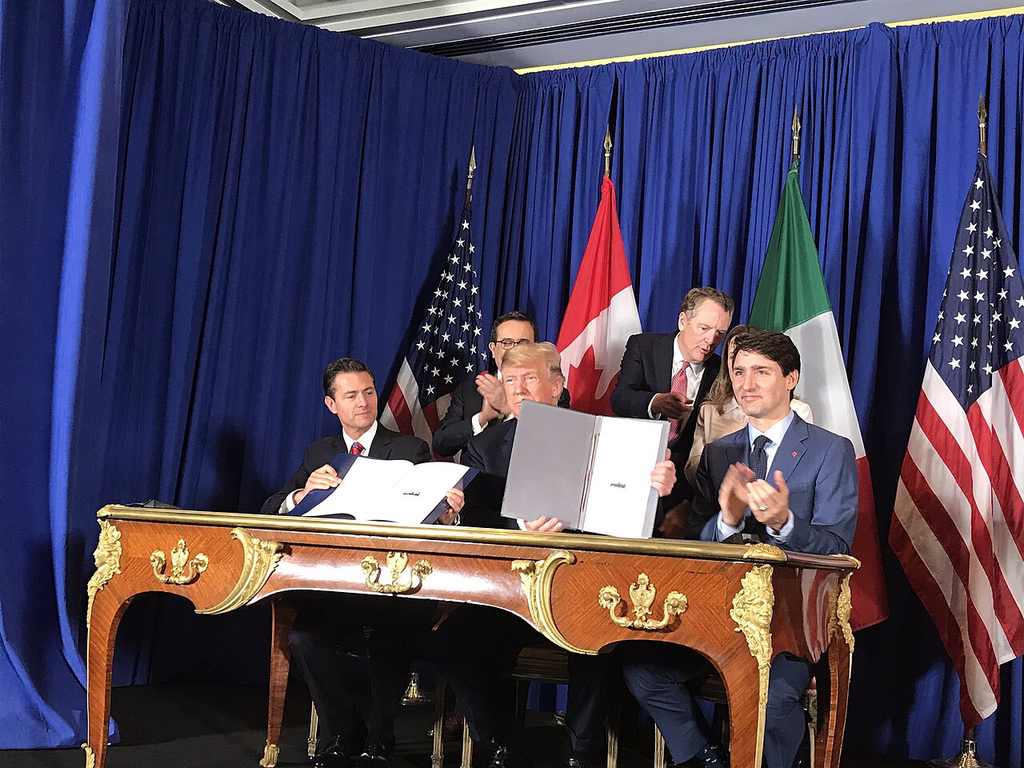

### Free trade area

**Example: USMCA**

A Mexican-built car needs proof that it meets USMCA origin rules. The three members can set different tariffs on cars from Japan.

[figure not shown]

### Customs union

**Example: Southern African Customs Union**

Five Southern African countries apply a common external tariff. Goods produced within SACU move among members without customs duties.

[figure not shown]

### Single market

**Example: European Union**

Goods, services, capital, and people move under shared rules. A French firm can hire an Italian citizen without a work permit.

Deeper integration removes more border barriers and constrains more national policy choices. The euro area adds a shared currency.

[USTR: USMCA rules of origin](https://ustr.gov/trade-agreements/wto-multilateral-affairs/wto-issues/customs-issues/rules-origin); [SACU: common external tariff](https://www.sacu.int/about-sacu/history-of-sacu); [European Commission: single market](https://commission.europa.eu/topics/single-market_en). Images: U.S. Treasury, public domain; SACU map by Htonl, public domain; EU flags by Fred Romero, CC BY 2.0, via Wikimedia Commons.

## Reflection: return to your IB Voice

Does the logic that created the MFA also explain how it ended?

## Monday: private enforcement in the diamond trade

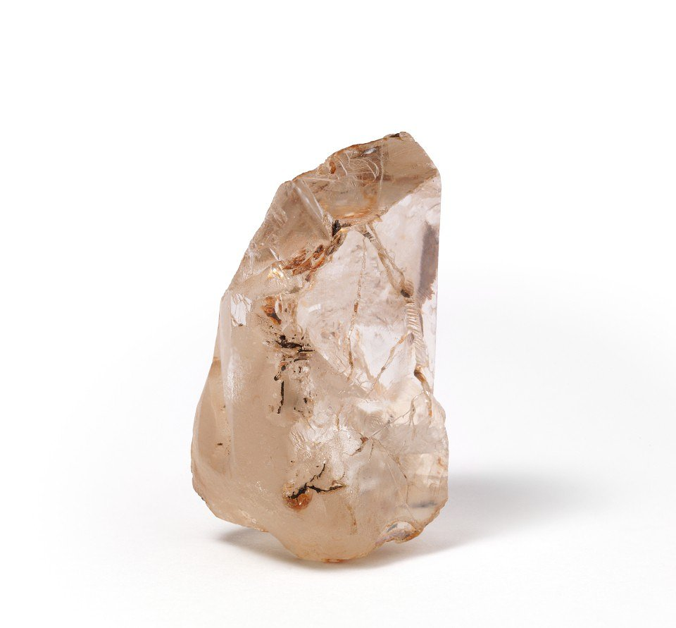

Why might firms rely on private rules to enforce a trading agreement?

Bernstein examines reputation and dispute resolution in the diamond trade.

Photograph: [Wikimedia Commons](https://commons.wikimedia.org/wiki/File:Rough_Diamond.jpg), CC0.

## Module 3 summary and beyond

- Borders divide business among different currencies, laws, tax systems, and trade rules.
- Those differences determine which cross-border activities are feasible, profitable, and risky.
- Firms respond through choices about sourcing, financing, ownership, legal structure, and political engagement.
- Those choices distribute gains and losses, create dependencies, and shape how shocks travel.
- The rest of the course examines how firms organize around these constraints and how (and why) firms and governments try to change them.